# Biostat 212a Homework 6

Due Mar 22, 2024 @ 11:59PM

Author

Zongzhe Lin UID:206328707

Published

March 20, 2024

Load R libraries.

```r
library(tidyverse)
library(tidymodels)
library(readr)
library(tswge)
library(ggplot2)
library(ggthemes)
library(dplyr)
library(glmnet)
library(tidyr)
library(purrr)
library(randomForest)
library(caret)
library(stats)
library(data.table)
library(recipes)
library(embed)
library(tidytext)
library(yardstick)
library(rsample)
library(ranger)
library(tune)
library(xgboost)
library(doParallel)
acfdf <- function(vec) {
    vacf <- acf(vec, plot = F)
    with(vacf, data.frame(lag, acf))
}
ggacf <- function(vec) {
    ac <- acfdf(vec)
    ggplot(data = ac, aes(x = lag, y = acf)) + geom_hline(aes(yintercept = 0)) +
        geom_segment(mapping = aes(xend = lag, yend = 0))
}

tplot <- function(vec) {
    df <- data.frame(X = vec, t = seq_along(vec))
    ggplot(data = df, aes(x = t, y = X)) + geom_line()
}
```

## 1 New York Stock Exchange (NYSE) data (1962-1986) (140 pts)

The [`NYSE.csv`](https://raw.githubusercontent.com/ucla-econ-425t/2023winter/master/slides/data/NYSE.csv) file contains three daily time series from the New York Stock Exchange (NYSE) for the period Dec 3, 1962-Dec 31, 1986 (6,051 trading days).

- `Log trading volume` ($v_t$): This is the fraction of all outstanding shares that are traded on that day, relative to a 100-day moving average of past turnover, on the log scale.
- `Dow Jones return` ($r_t$): This is the difference between the log of the Dow Jones Industrial Index on consecutive trading days.
- `Log volatility` ($z_t$): This is based on the absolute values of daily price movements.

```r
# Read in NYSE data from url

url = "https://raw.githubusercontent.com/ucla-biostat-212a/2024winter/master/slides/data/NYSE.csv"
NYSE <- read_csv(url)

NYSE
```

```
# A tibble: 6,051 × 6
   date       day_of_week DJ_return log_volume log_volatility train
   <date>     <chr>           <dbl>      <dbl>          <dbl> <lgl>
 1 1962-12-03 mon         -0.00446     0.0326           -13.1 TRUE
 2 1962-12-04 tues         0.00781     0.346            -11.7 TRUE
 3 1962-12-05 wed          0.00384     0.525            -11.7 TRUE
 4 1962-12-06 thur        -0.00346     0.210            -11.6 TRUE
 5 1962-12-07 fri          0.000568    0.0442           -11.7 TRUE
 6 1962-12-10 mon         -0.0108      0.133            -10.9 TRUE
 7 1962-12-11 tues         0.000124   -0.0115           -11.0 TRUE
 8 1962-12-12 wed          0.00336     0.00161          -11.0 TRUE
 9 1962-12-13 thur        -0.00330    -0.106            -11.0 TRUE
10 1962-12-14 fri          0.00447    -0.138            -11.0 TRUE
# ℹ 6,041 more rows
```

The **autocorrelation** at lag $\ell$ is the correlation of all pairs $(v_t, v_{t-\ell})$ that are $\ell$ trading days apart. These sizable correlations give us confidence that past values will be helpful in predicting the future.

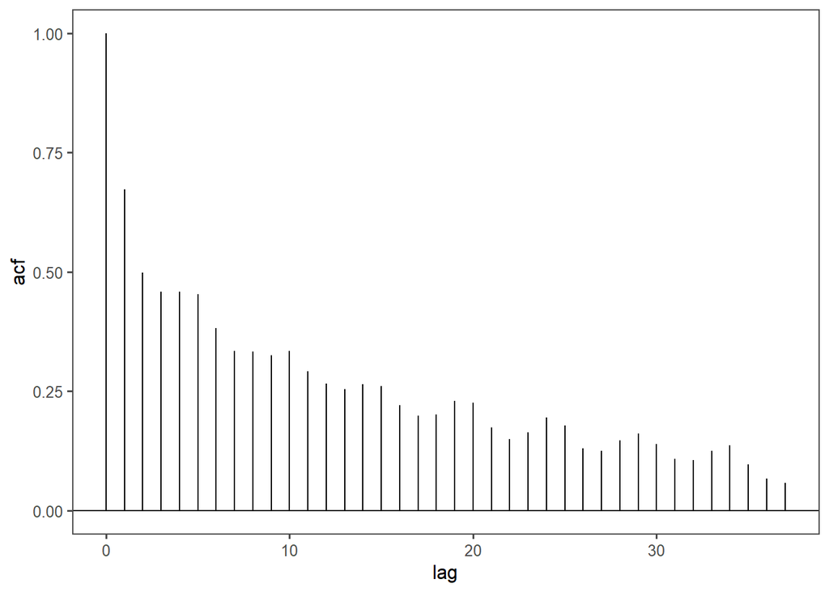

Figure 1: The autocorrelation function for log volume. We see that nearby values are fairly strongly correlated, with correlations above 0.2 as far as 20 days apart.

```r
ggacf(NYSE$log_volume) + ggthemes::theme_few()
```

Do a similar plot for (1) the correlation between $v_t$ and lag $\ell$ `Dow Jones return` $r_{t-\ell}$ and (2) correlation between $v_t$ and lag $\ell$ `Log volatility` $z_{t-\ell}$.

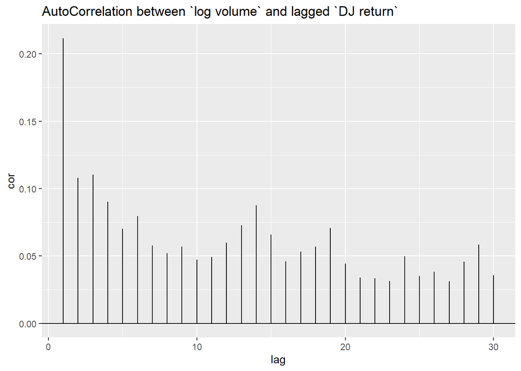

```r
seq(1, 30) %>%
  map(function(x) {cor(NYSE$log_volume , lag(NYSE$DJ_return, x), use = "pairwise.complete.obs")}) %>%
  unlist() %>%
  tibble(lag = 1:30, cor = .) %>%
  ggplot(aes(x = lag, y = cor)) +
  geom_hline(aes(yintercept = 0)) +
  geom_segment(mapping = aes(xend = lag, yend = 0)) +
  ggtitle("AutoCorrelation between `log volume` and lagged `DJ return`")
```

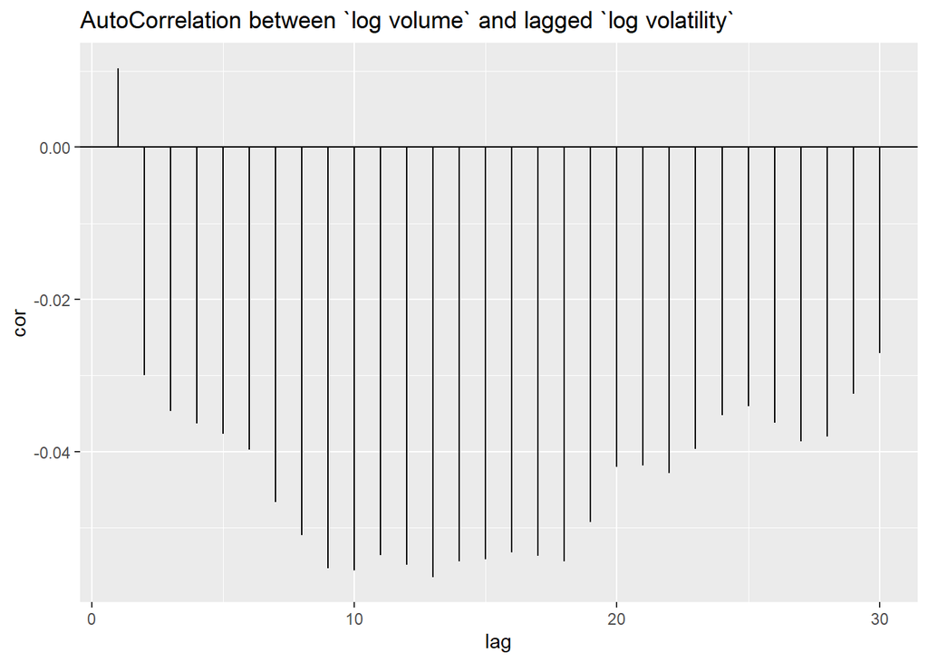

```r
seq(1, 30) %>%
  map(function(x) {cor(NYSE$log_volume , lag(NYSE$log_volatility, x), use = "pairwise.complete.obs")}) %>%
  unlist() %>%
  tibble(lag = 1:30, cor = .) %>%
  ggplot(aes(x = lag, y = cor)) +
  geom_hline(aes(yintercept = 0)) +
  geom_segment(mapping = aes(xend = lag, yend = 0)) +
  ggtitle("AutoCorrelation between `log volume` and lagged `log volatility`")
```

### 1.1 Project goal

Our goal is to forecast daily `Log trading volume`, using various machine learning algorithms we learnt in this class.

The data set is already split into train (before Jan 1st, 1980, $n_{\text{train}} = 4,281$) and test (after Jan 1st, 1980, $n_{\text{test}} = 1,770$) sets.

In general, we will tune the lag $L$ to acheive best forecasting performance. In this project, we would fix $L=5$. That is we always use the previous five trading days’ data to forecast today’s `log trading volume`.

Pay attention to the nuance of splitting time series data for cross validation. Study and use the [`time-series`](https://www.tidymodels.org/learn/models/time-series/) functionality in tidymodels. Make sure to use the same splits when tuning different machine learning algorithms.

Use the $R^2$ between forecast and actual values as the cross validation and test evaluation criterion.

### 1.2 Baseline method (20 pts)

We use the straw man (use yesterday’s value of `log trading volume` to predict that of today) as the baseline method. Evaluate the $R^2$ of this method on the test data.

```r
# Lag: look back L trading days
# Do not need to include, as we included them in receipe

L = 5
for(i in seq(1, L)) {
  NYSE <- NYSE %>%
    mutate(!!paste("DJ_return_lag", i, sep = "") := lag(NYSE$DJ_return, i),
           !!paste("log_volume_lag", i, sep = "") := lag(NYSE$log_volume, i),
           !!paste("log_volatility_lag", i, sep = "") := lag(NYSE$log_volatility, i))
}


NYSE <-   NYSE %>% na.omit()
```

```r
# Drop beginning trading days which lack some lagged variables
NYSE_other <- NYSE %>%
  filter(train == 'TRUE') %>%
  select(-train) %>%
  drop_na()
dim(NYSE_other)
```

```
[1] 4276   20
```

```r
NYSE_test = NYSE %>%
  filter(train == 'FALSE') %>%
  select(-train) %>%
  drop_na()
dim(NYSE_test)
```

```
[1] 1770   20
```

```r
library(yardstick)
# cor(NYSE_test$log_volume, NYSE_test$log_volume_lag1) %>% round(2)
r2_test_strawman =  rsq_vec(NYSE_test$log_volume, lag(NYSE_test$log_volume, 1)) %>% round(2)
print(paste("Straw man test R2: ", r2_test_strawman))
```

```
[1] "Straw man test R2:  0.35"
```

```r
set.seed(1101)

# Define the number of folds for cross-validation
n_folds <- 10
n_repeats <- 5
cv_r2 <- numeric(n_folds * n_repeats)

# Manually create cross-validation folds
folds <- createFolds(NYSE_other$log_volume, k = n_folds, list = TRUE, returnTrain = FALSE)

# Repeat the cross-validation process
for (r in seq_len(n_repeats)) {
  for (f in seq_along(folds)) {
    # Extract the test fold
    test_indices <- folds[[f]]
    cv_test_set <- NYSE_other[test_indices, ]

    # Compute the "straw man" predictions
    strawman_preds <- stats::lag(cv_test_set$log_volume, -5)

    # Remove the NA value caused by the lag at the end of the vector
    strawman_preds <- strawman_preds[1:(length(strawman_preds)-1)]
    actual_values <- cv_test_set$log_volume[2:length(cv_test_set$log_volume)]

    # Calculate the R^2 for this fold
    cv_r2_value <- rsq_vec(actual_values, strawman_preds)

    # Store the R^2 value for this fold
    cv_r2[(r - 1) * n_folds + f] <- cv_r2_value
  }
}

# Calculate the average R^2 across all folds and repeats
cv_r2_mean <- mean(cv_r2, na.rm = TRUE)

print(paste("Cross-validation Straw man R2: ", round(cv_r2_mean, 2)))
```

```
[1] "Cross-validation Straw man R2:  0.17"
```

### 1.3 Autoregression (AR) forecaster (30 pts)

- Let
  $$y = \begin{pmatrix} v_{L+1} \\ v_{L+2} \\ v_{L+3} \\ \vdots \\ v_T \end{pmatrix}, \quad M = \begin{pmatrix}
  1 & v_L & v_{L-1} & \cdots & v_1 \\
  1 & v_{L+1} & v_{L} & \cdots & v_2 \\
  \vdots & \vdots & \vdots & \ddots & \vdots \\
  1 & v_{T-1} & v_{T-2} & \cdots & v_{T-L}
  \end{pmatrix}.$$
- Fit an ordinary least squares (OLS) regression of $y$ on $M$, giving
  $$\hat v_t = \hat \beta_0 + \hat \beta_1 v_{t-1} + \hat \beta_2 v_{t-2} + \cdots + \hat \beta_L v_{t-L},$$
  known as an **order-**$L$ autoregression model or **AR(**$L$).
- Before we start the model training, let’s talk about time series resampling. We will use the `rolling_origin` function in the `rsample` package to create a time series cross-validation plan.
- When the data have a strong time component, a resampling method should support modeling to estimate seasonal and other temporal trends within the data. A technique that randomly samples values from the training set can disrupt the model’s ability to estimate these patterns.

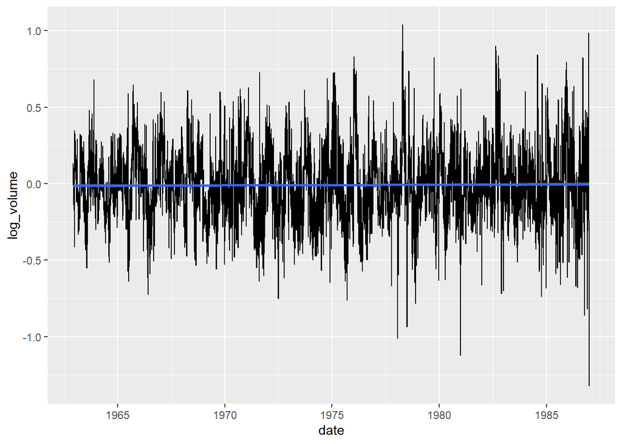

```r
NYSE %>%
  ggplot(aes(x = date, y = log_volume)) +
  geom_line() +
  geom_smooth(method = "lm")
```

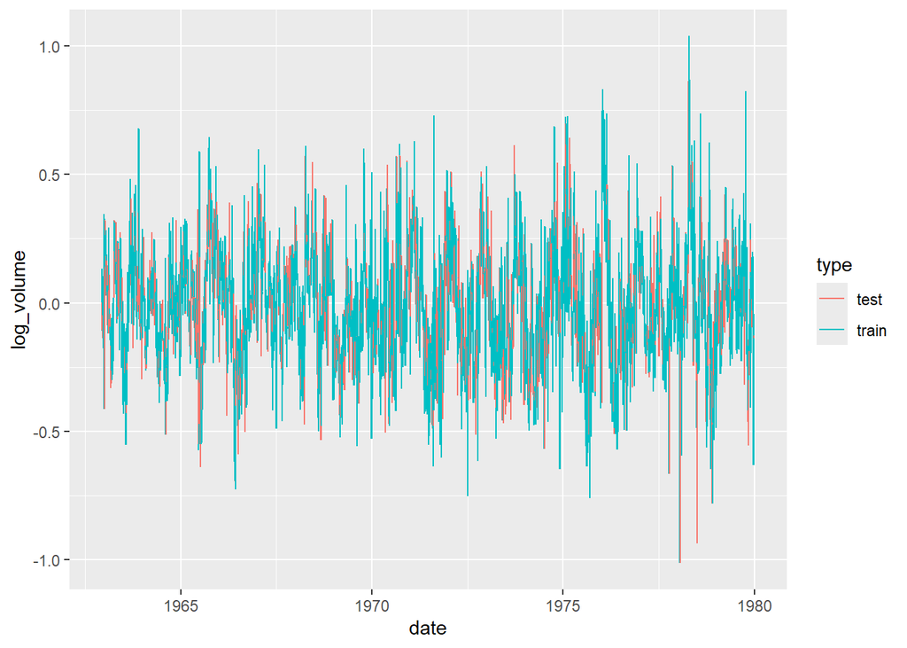

```r
wrong_split <- initial_split(NYSE_other)

bind_rows(
  training(wrong_split) %>% mutate(type = "train"),
  testing(wrong_split) %>% mutate(type = "test")
) %>%
  ggplot(aes(x = date, y = log_volume, color = type, group = NA)) +
  geom_line()
```

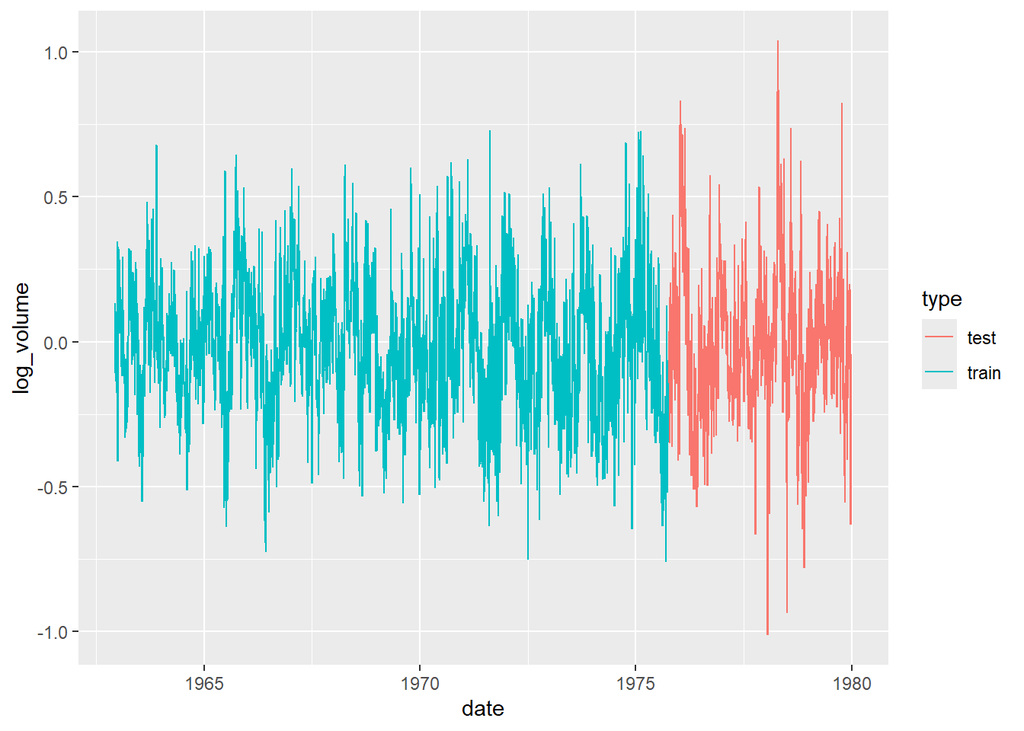

```r
correct_split <- initial_time_split(NYSE_other %>% arrange(date))

bind_rows(
  training(correct_split) %>% mutate(type = "train"),
  testing(correct_split) %>% mutate(type = "test")
) %>%
  ggplot(aes(x = date, y = log_volume, color = type, group = NA)) +
  geom_line()
```

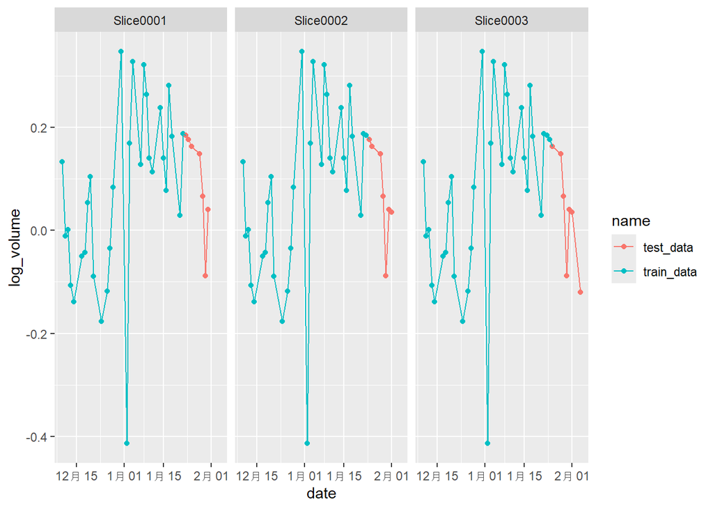

```r
rolling_origin(NYSE_other %>% arrange(date), initial = 30, assess = 7) %>%
#sliding_period(NYSE_other %>% arrange(date), date, period = "day", lookback = Inf, assess_stop = 1) %>%
  mutate(train_data = map(splits, analysis),
         test_data = map(splits, assessment)) %>%
  select(-splits) %>%
  pivot_longer(-id) %>%
  filter(id %in% c("Slice0001", "Slice0002", "Slice0003")) %>%
  unnest(value) %>%
  ggplot(aes(x = date, y = log_volume, color = name, group = NA)) +
  geom_point() +
  geom_line() +
  facet_wrap(~id, scales = "fixed")
```

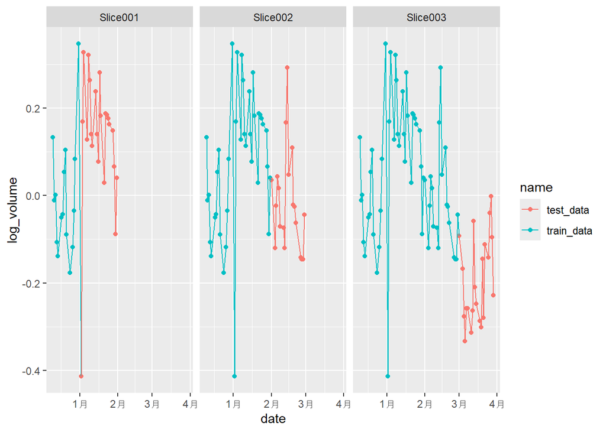

```r
sliding_period(NYSE_other %>% arrange(date),
               date, period = "month", lookback = Inf, assess_stop = 1) %>%
  mutate(train_data = map(splits, analysis),
         test_data = map(splits, assessment)) %>%
  select(-splits) %>%
  pivot_longer(-id) %>%
  filter(id %in% c("Slice001", "Slice002", "Slice003")) %>%
  unnest(value) %>%
  ggplot(aes(x = date, y = log_volume, color = name, group = NA)) +
  geom_point() +
  geom_line() +
  facet_wrap(~id, scales = "fixed")
```

- Rolling forecast origin resampling ([Hyndman and Athanasopoulos 2018](https://otexts.com/fpp3/)) provides a method that emulates how time series data is often partitioned in practice, estimating the model with historical data and evaluating it with the most recent data.
- Tune AR(5) with elastic net (lasso + ridge) regularization using all 3 features on the training data, and evaluate the test performance.

### 1.4 Preprocessing

```r
en_receipe <-
  recipe(log_volume ~ ., data = NYSE_other) %>%
  step_dummy(all_nominal(), -all_outcomes()) %>%
  step_normalize(all_numeric_predictors(), -all_outcomes()) %>%
  step_naomit(all_predictors()) %>%
  prep(data = NYSE_other)
```

### 1.5 Model training

```r
### Model
enet_mod <-
  linear_reg(penalty = tune(), mixture = 0.5) %>%
  set_engine("glmnet")

en_wf <-
  workflow() %>%
  add_model(enet_mod) %>%
  add_recipe(en_receipe %>% step_rm(date) %>% step_indicate_na())

folds <- NYSE_other %>% arrange(date) %>%
    sliding_period(date, period = "month", lookback = Inf, assess_stop = 1)
  # rolling_origin(initial = 5, assess = 1)

month_folds <- NYSE_other %>%
  sliding_period(
    date,
    "month",
    lookback = Inf,
    skip = 4)

lambda_grid <-
  grid_regular(penalty(range = c(-8, -7), trans = log10_trans()), levels = 3)

en_fit <- tune_grid(en_wf, resamples = month_folds, grid = lambda_grid) %>%
     collect_metrics()
```

- Hint: [Workflow: Lasso](https://ucla-biostat-212a.github.io/2024winter/slides/06-modelselection/workflow_lasso.html) is a good starting point.

```r
# Define the recipe without prepping it
en_recipe <-
  recipe(log_volume ~ ., data = NYSE_other) %>%
  step_dummy(all_nominal(), -all_outcomes()) %>%
  step_normalize(all_numeric_predictors(), -all_outcomes()) %>%
  step_naomit(all_predictors()) %>%
  step_rm(date)  # Remove the date column if it's not needed for modeling

final_enet_mod <- linear_reg(penalty = best_penalty, mixture = 0.5) %>%
  set_engine("glmnet")

best_result <- en_fit %>%
  filter(.metric == "rmse") %>%
  arrange(mean) %>%
  dplyr::slice(1)

# Extract the best penalty value
best_penalty <- best_result$penalty

# Create a new workflow with the recipe and the model
final_wf <- workflow() %>%
  add_recipe(en_recipe) %>%
  add_model(final_enet_mod)

# Fit the workflow with the full training data
final_fit <- final_wf %>%
  fit(data = NYSE_other)

# Predict on the test set
test_predictions <- predict(final_fit, new_data = NYSE_test)

# Extract the predicted values and actual values to calculate the test R2
predicted <- test_predictions$.pred

# Calculate the test R2
actuals <- NYSE_test$log_volume
test_r2 <- rsq_vec(truth = actuals, estimate = predicted)

# Output the test R2
print(paste("Test R2: ", round(test_r2, 2)))
```

```
[1] "Test R2:  0.55"
```

```r
NYSE_other <- NYSE_other %>%
  select(-date, -day_of_week)

NYSE_test <- NYSE_test %>%
  select(-date, -day_of_week)
```

```r
set.seed(1101)

en_recipe <-
  recipe(log_volume ~ ., data = NYSE_other) %>%
  step_dummy(all_nominal(), -all_outcomes()) %>%
  step_normalize(all_numeric_predictors(), -all_outcomes()) %>%
  step_naomit(all_predictors())

# Create a new workflow with the updated recipe and the model
en_wf <- workflow() %>%
  add_recipe(en_recipe) %>%
  add_model(final_enet_mod)


# Define the number of folds for cross-validation
n_folds <- 10
n_repeats <- 5
cv_r2 <- numeric(n_folds * n_repeats)

# Manually create cross-validation folds using caret's createFolds
folds <- createFolds(NYSE_other$log_volume, k = n_folds, list = TRUE, returnTrain = FALSE)

# Repeat the cross-validation process
for (r in seq_len(n_repeats)) {
  for (f in seq_along(folds)) {
    # Extract the training and test fold
    test_indices <- folds[[f]]
    train_indices <- setdiff(seq_len(nrow(NYSE_other)), test_indices)

    train_set <- NYSE_other[train_indices, ]
    test_set <- NYSE_other[test_indices, ]

    # Fit the model to the training data
    fit <- en_wf %>%
      fit(data = train_set)

    # Predict on the test_set using the fitted model
    predictions <- predict(fit, new_data = test_set)

    # Ensure predictions and actuals are numeric vectors
    actuals <- test_set$log_volume
    preds <- predictions$.pred %>% as.numeric()

    # Calculate the R^2 for this fold
    cv_r2_value <- rsq_vec(truth = actuals, estimate = preds)

    # Store the R^2 value for this fold
    cv_r2[(r - 1) * n_folds + f] <- cv_r2_value
  }
}

# Calculate the average R^2 across all folds and repeats
cv_r2_mean <- mean(cv_r2, na.rm = TRUE)

print(paste("Cross-validation AR5 R2: ", round(cv_r2_mean, 2)))
```

```
[1] "Cross-validation AR5 R2:  0.63"
```

### 1.6 Random forest forecaster (30pts)

- Use the same features as in AR($L$) for the random forest. Tune the random forest and evaluate the test performance.
- Hint: [Workflow: Random Forest for Prediction](https://ucla-biostat-212a.github.io/2024winter/slides/08-tree/workflow_rf_reg.html) is a good starting point.

```r
url = "https://raw.githubusercontent.com/ucla-biostat-212a/2024winter/master/slides/data/NYSE.csv"
NYSE <- read_csv(url)

L = 5
for(i in seq(1, L)) {
  NYSE <- NYSE %>%
    mutate(!!paste("DJ_return_lag", i, sep = "") := lag(NYSE$DJ_return, i),
           !!paste("log_volume_lag", i, sep = "") := lag(NYSE$log_volume, i),
           !!paste("log_volatility_lag", i, sep = "") := lag(NYSE$log_volatility, i))
}

NYSE <-   NYSE %>% na.omit()

NYSE_other <- NYSE %>%
  filter(train == 'TRUE') %>%
  select(-train) %>%
  drop_na()
dim(NYSE_other)
```

```
[1] 4276   20
```

```r
NYSE_test = NYSE %>%
  filter(train == 'FALSE') %>%
  select(-train) %>%
  drop_na()
dim(NYSE_test)
```

```
[1] 1770   20
```

```r
NYSE_other <- NYSE_other %>% select(-date, -day_of_week)
NYSE_test <- NYSE_test %>% select(-date, -day_of_week)
```

```r
set.seed(1101)

# Recipe definition
rf_recipe <- recipe(log_volume ~ ., data = NYSE_other) %>%
  step_dummy(all_nominal(), -all_outcomes())

# Random Forest model definition
rf_model <- rand_forest(trees = tune(), mtry = tune(), min_n = tune()) %>%
  set_mode("regression") %>%
  set_engine("ranger")

# Workflow creation
rf_wf <- workflow() %>%
  add_recipe(rf_recipe) %>%
  add_model(rf_model)

# Cross-validation setup for hyper-parameter tuning
folds <- vfold_cv(NYSE_other, v = 10, strata = log_volume)

# Define the range for the `min_n` parameter
min_n_range <- range(20, 50)

# Redefine the tuning grid to include `min_n`
grid <- grid_regular(
  trees(range = c(50, 100)),
  mtry(range = c(2, 4)),
  min_n(min_n_range),
  levels = 2
)

# Model tuning using 10-fold cross-validation
rf_results <- tune_grid(
  rf_wf,
  resamples = folds,
  grid = grid,
  metrics = metric_set(rmse, rsq)
)

# Best model selection based on RMSE
best_rf <- select_best(rf_results, "rmse")

# Finalize the workflow with the best model parameters
final_rf_wf <- finalize_workflow(rf_wf, best_rf)

# Refit the best model to the entire non-test data (NYSE_other)
final_rf_fit <- final_rf_wf %>%
  fit(data = NYSE_other)

# Predict on the test set (NYSE_test)
test_predictions <- final_rf_fit %>%
  predict(new_data = NYSE_test)

# Extract the predictions and calculate R²
preds <- test_predictions$.pred %>% as.numeric()
actuals <- NYSE_test$log_volume

# Calculate R²
test_r2 <- rsq_vec(truth = actuals, estimate = preds)

# Output the test R², rounded to two decimal places
print(paste("Test R2 with Random Forest: ", round(test_r2, 2)))
```

```
[1] "Test R2 with Random Forest:  0.47"
```

```r
# Extract the cross-validated R^2 values from the tuning results
cv_r2_results <- rf_results %>%
  collect_metrics() %>%
  filter(.metric == "rsq")

# Calculate the mean CV R^2 across all folds and repeats
mean_cv_r2 <- cv_r2_results %>%
  summarise(mean_rsq = mean(mean)) %>%
  pull(mean_rsq)

# Output the mean CV R^2, rounded to two decimal places
print(paste("Cross-validation R2: ", round(mean_cv_r2, 2)))
```

```
[1] "Cross-validation R2:  0.61"
```